# Predicting House Prices

**Train** **Test**

# Exploring the Data

```r
library(ggplot2)
library(ggthemes)
library(tidyr)
library(Amelia)
library(caTools)
```

## Importing the Data

Use the `read.csv()` function to import the data labeled **Train**.

```r
data = read.csv("train.csv")

split = sample.split(data, SplitRatio = 0.7)
train = subset(data, split == TRUE)
test  = subset(data, split == FALSE)
```

## Understanding the Data

Here let’s see what we’re working with. We will use the `str` function to see how the data is structured and understand the classes of data we are working with. First, we can see there is a lot going on here. I’m going to organize the data into types.

```r
data %>%
     head(2) %>%
     str()
```

```
## 'data.frame':    2 obs. of  81 variables:
##  $ Id           : int  1 2
##  $ MSSubClass   : int  60 20
##  $ MSZoning     : Factor w/ 5 levels "C (all)","FV",..: 4 4
##  $ LotFrontage  : int  65 80
##  $ LotArea      : int  8450 9600
##  $ Street       : Factor w/ 2 levels "Grvl","Pave": 2 2
##  $ Alley        : Factor w/ 2 levels "Grvl","Pave": NA NA
##  $ LotShape     : Factor w/ 4 levels "IR1","IR2","IR3",..: 4 4
##  $ LandContour  : Factor w/ 4 levels "Bnk","HLS","Low",..: 4 4
##  $ Utilities    : Factor w/ 2 levels "AllPub","NoSeWa": 1 1
##  $ LotConfig    : Factor w/ 5 levels "Corner","CulDSac",..: 5 3
##  $ LandSlope    : Factor w/ 3 levels "Gtl","Mod","Sev": 1 1
##  $ Neighborhood : Factor w/ 25 levels "Blmngtn","Blueste",..: 6 25
##  $ Condition1   : Factor w/ 9 levels "Artery","Feedr",..: 3 2
```

[output cut: 67 more lines]

```r
classes = data %>%
     lapply(class) %>%
     as.character()
```

Next, let’s see if there is anything missing in the data. We can do this by calling the `missmap` function from the `Amelia` package.

```r
dim(data)
```

```
## [1] 1460   81
```

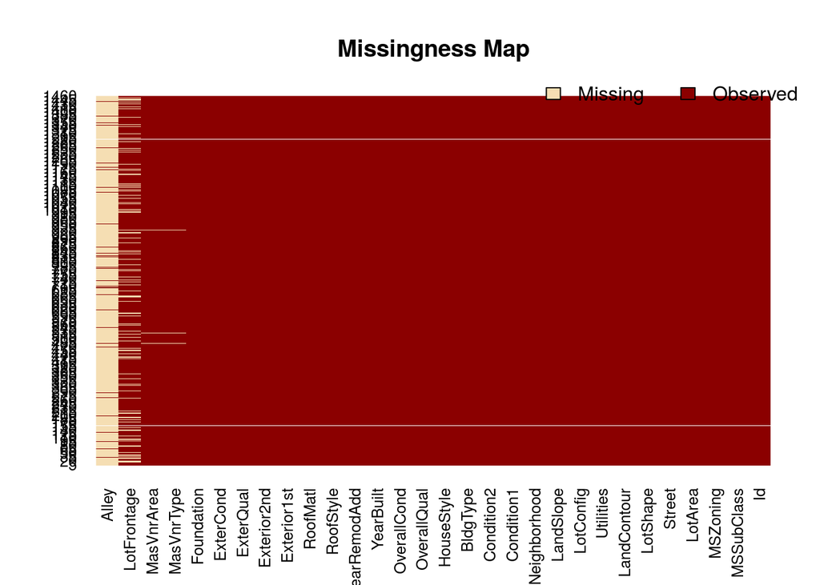

```r
missmap(data[,1:30])
```

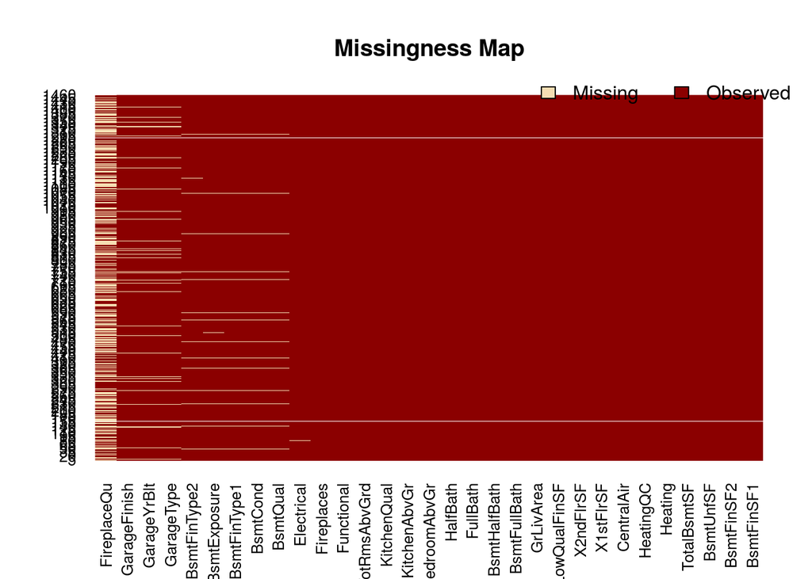

```r
missmap(data[,31:61])
```

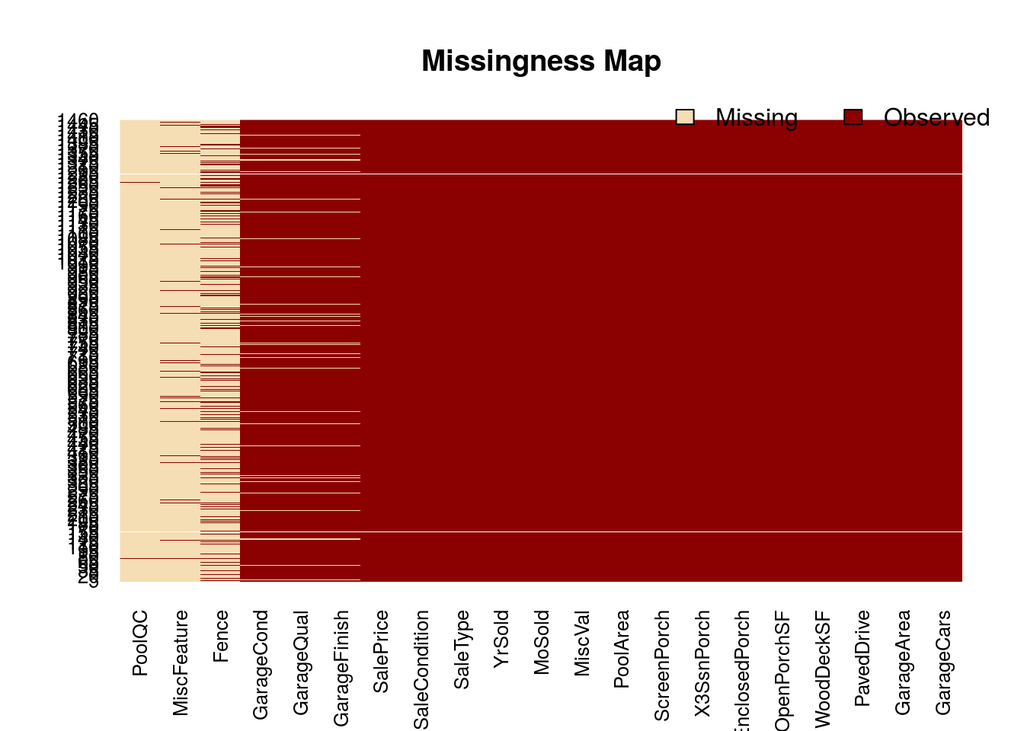

```r
missmap(data[,61:81])
```

So, this isn’t a complete dataset. Let’s look all the numeric data to see the distributions and then also plot the nummber of missing values.

[figure not shown]

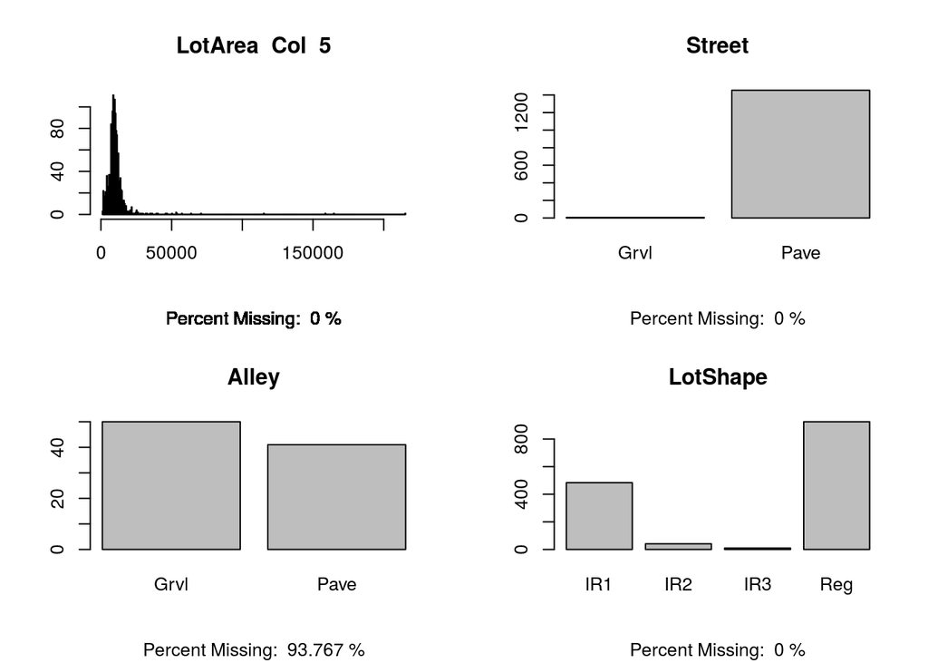

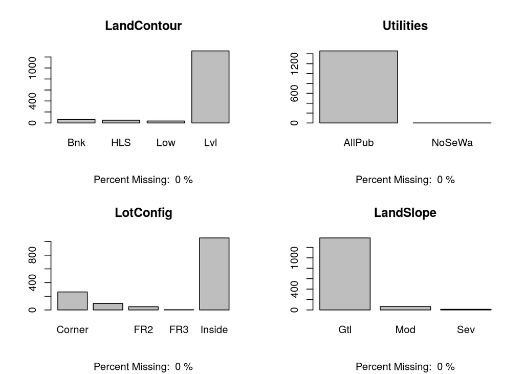

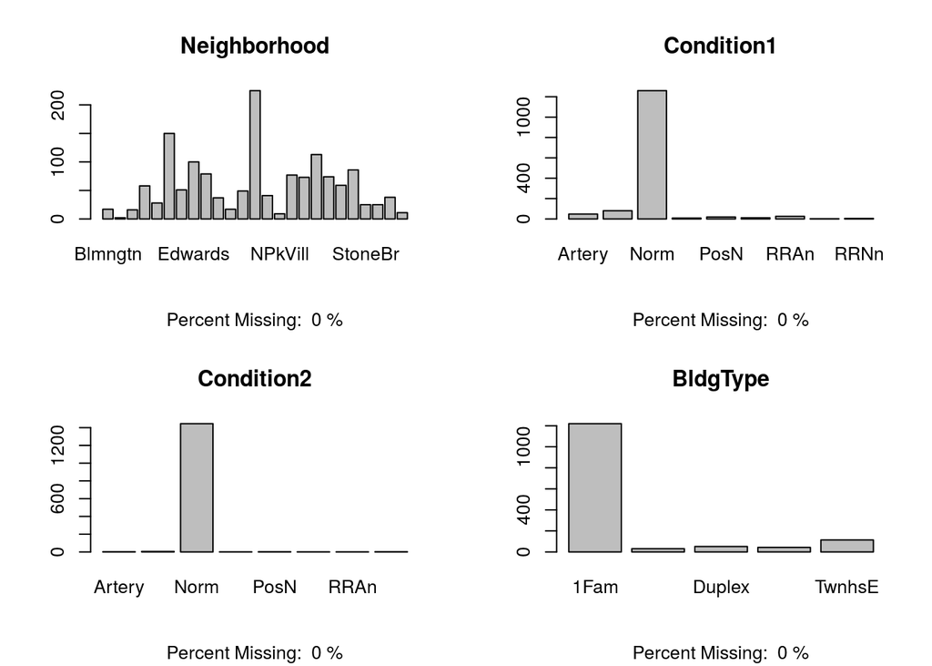

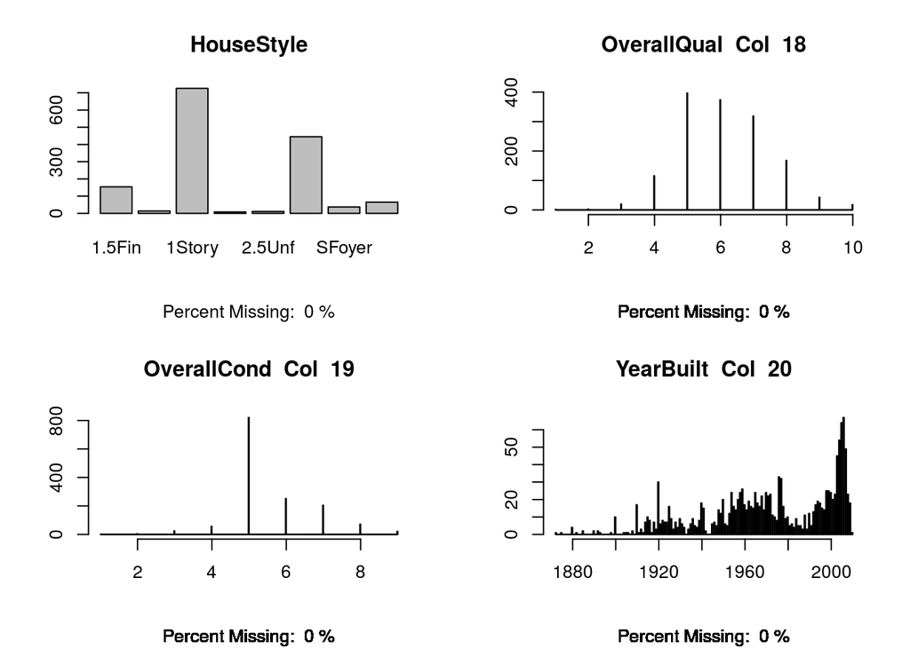

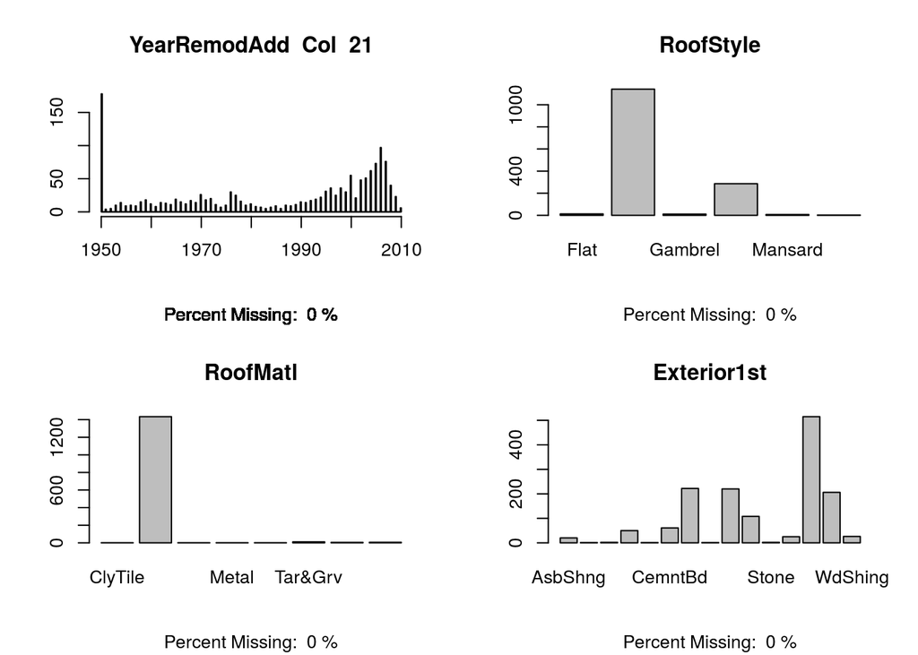

[figure not shown]

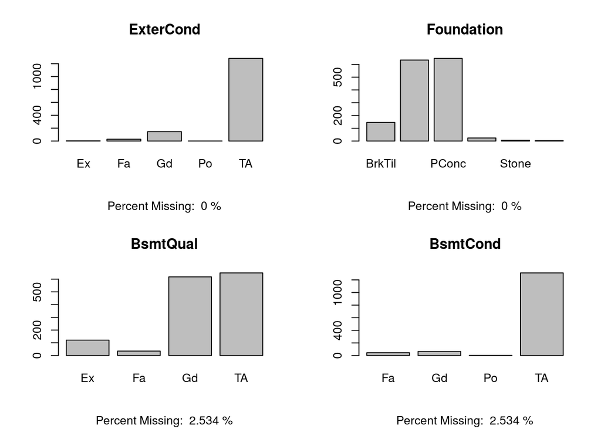

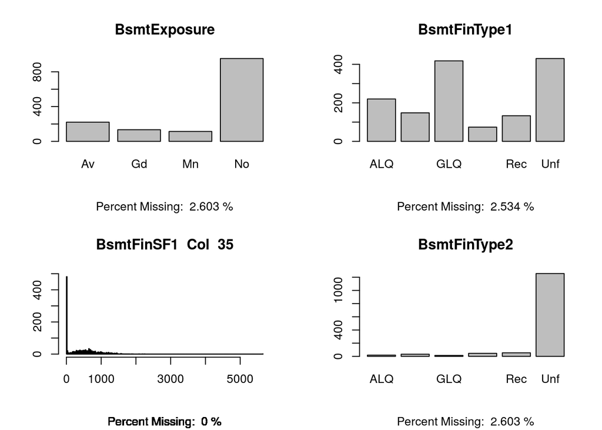

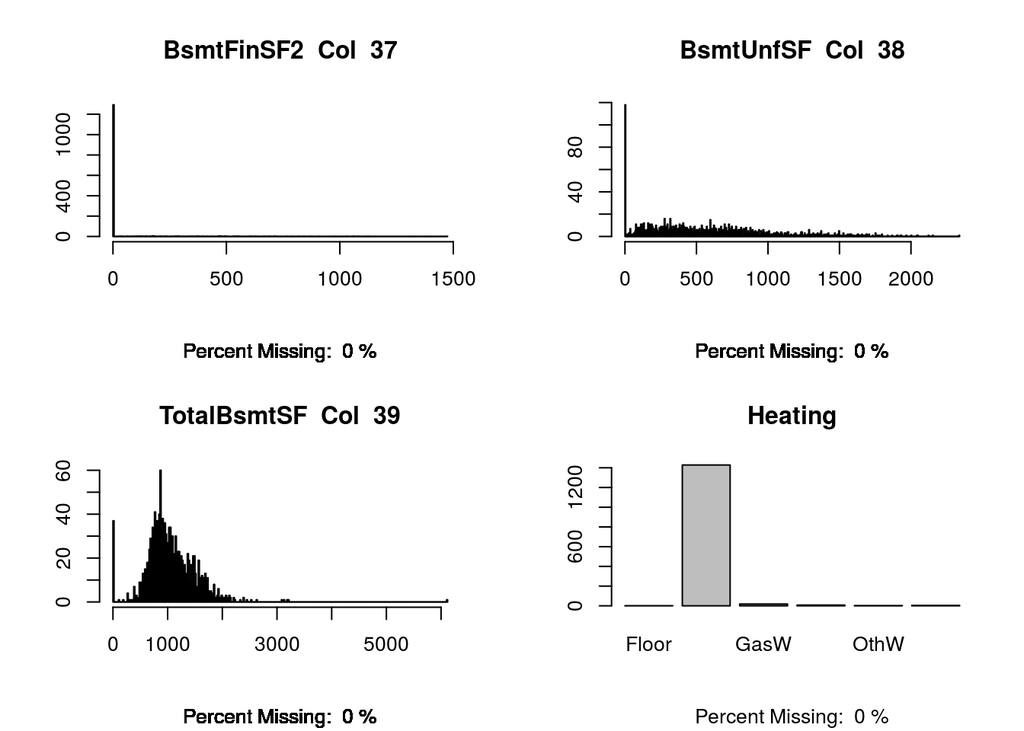

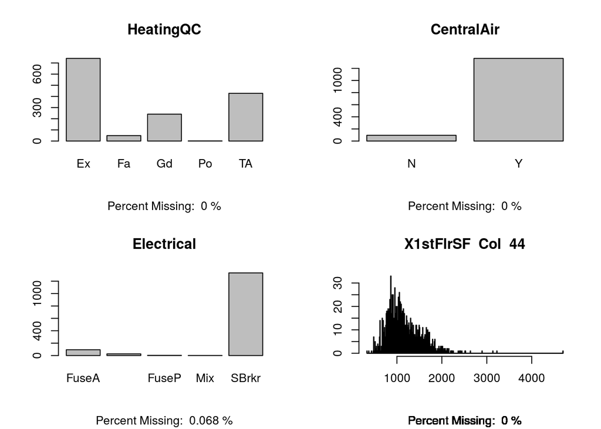

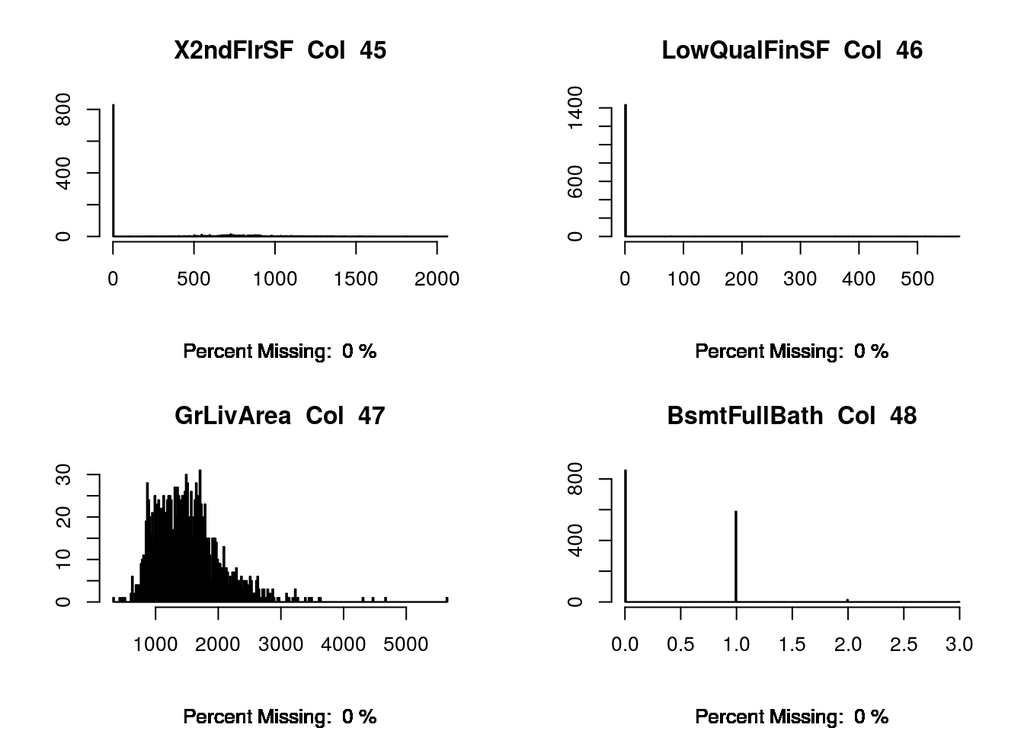

[8 more figures not shown]

```r
par(mfrow = c(2,2))
for(i in 1:ncol(data)) {
     if(classes[i] == "integer") {
           hist(data[,i],
               main = paste(names(data)[i], " Col ", i),
               breaks = length(unique(data[,1]))/4,
               xlab = "",
               ylab = "",
               sub = paste("Percent Missing: ", round(complete.cases(data[,i])/length(data[,i]), 2)*100, "%"))
     }
         else if (classes[i] == "factor") {
              plot(data[i], main = colnames(data)[i],
                   sub = paste("Percent Missing: ", round(sum(is.na(data[,i]))/length(data[,i]), 5)*100, "%"))
         }
}
```

[figure not shown]

```r
par(mfrow = c(1,1))
```

```r
factorCols  = classes == "factor"
numericCols = classes == "integer"
#
# data = cbind(data[,numericCols], data[,factorCols])

str(data)
```

```
## 'data.frame':    1460 obs. of  81 variables:
##  $ Id           : int  1 2 3 4 5 6 7 8 9 10 ...
##  $ MSSubClass   : int  60 20 60 70 60 50 20 60 50 190 ...
##  $ MSZoning     : Factor w/ 5 levels "C (all)","FV",..: 4 4 4 4 4 4 4 4 5 4 ...
##  $ LotFrontage  : int  65 80 68 60 84 85 75 NA 51 50 ...
##  $ LotArea      : int  8450 9600 11250 9550 14260 14115 10084 10382 6120 7420 ...
##  $ Street       : Factor w/ 2 levels "Grvl","Pave": 2 2 2 2 2 2 2 2 2 2 ...
##  $ Alley        : Factor w/ 2 levels "Grvl","Pave": NA NA NA NA NA NA NA NA NA NA ...
##  $ LotShape     : Factor w/ 4 levels "IR1","IR2","IR3",..: 4 4 1 1 1 1 4 1 4 4 ...
##  $ LandContour  : Factor w/ 4 levels "Bnk","HLS","Low",..: 4 4 4 4 4 4 4 4 4 4 ...
##  $ Utilities    : Factor w/ 2 levels "AllPub","NoSeWa": 1 1 1 1 1 1 1 1 1 1 ...
##  $ LotConfig    : Factor w/ 5 levels "Corner","CulDSac",..: 5 3 5 1 3 5 5 1 5 1 ...
##  $ LandSlope    : Factor w/ 3 levels "Gtl","Mod","Sev": 1 1 1 1 1 1 1 1 1 1 ...
##  $ Neighborhood : Factor w/ 25 levels "Blmngtn","Blueste",..: 6 25 6 7 14 12 21 17 18 4 ...
##  $ Condition1   : Factor w/ 9 levels "Artery","Feedr",..: 3 2 3 3 3 3 3 5 1 1 ...
```

[output cut: 67 more lines]

```r
numericDataTrain = train[numericCols]
numericDataTest  = test[numericCols]

numericDataTest = numericDataTest[,-c(3, 26)]

trainNumeric = train[numericCols]
trainNumeric = trainNumeric[, -c(3,26)]
```

```r
theLm = lm(SalePrice ~ ., data = na.omit(numericDataTrain), direction = "back")
summary(theLm)
```

```
##
## Call:
## lm(formula = SalePrice ~ ., data = na.omit(numericDataTrain),
##     direction = "back")
##
## Residuals:
##     Min      1Q  Median      3Q     Max
## -128263  -14516    -595   13328  142282
##
## Coefficients: (2 not defined because of singularities)
##                 Estimate Std. Error t value Pr(>|t|)
## (Intercept)   -1.198e+06  1.460e+06  -0.821 0.412189
## Id            -1.729e+00  2.257e+00  -0.766 0.444000
## MSSubClass    -1.058e+02  3.018e+01  -3.505 0.000484 ***
## LotFrontage   -2.571e+01  5.968e+01  -0.431 0.666673
## LotArea        1.768e+00  2.675e-01   6.611 7.34e-11 ***
## OverallQual    1.486e+04  1.274e+03  11.666  < 2e-16 ***
## OverallCond    5.457e+03  1.175e+03   4.644 4.05e-06 ***
## YearBuilt      3.003e+02  7.272e+01   4.129 4.06e-05 ***
## YearRemodAdd   1.915e+02  7.278e+01   2.631 0.008696 **
## MasVnrArea     2.668e+01  6.007e+00   4.442 1.03e-05 ***
## BsmtFinSF1     4.694e+01  5.309e+00   8.841  < 2e-16 ***
## BsmtFinSF2     1.673e+01  8.135e+00   2.057 0.040039 *
## BsmtUnfSF      2.002e+01  4.711e+00   4.249 2.42e-05 ***
## TotalBsmtSF           NA         NA      NA       NA
## X1stFlrSF      6.423e+01  6.496e+00   9.888  < 2e-16 ***
## X2ndFlrSF      7.096e+01  5.408e+00  13.119  < 2e-16 ***
## LowQualFinSF  -1.539e+00  2.821e+01  -0.055 0.956522
## GrLivArea             NA         NA      NA       NA
## BsmtFullBath  -1.952e+02  2.789e+03  -0.070 0.944211
## BsmtHalfBath  -5.740e+03  4.282e+03  -1.341 0.180493
## FullBath      -4.924e+03  3.025e+03  -1.628 0.104027
## HalfBath      -5.566e+03  2.880e+03  -1.933 0.053663 .
## BedroomAbvGr  -1.070e+04  1.827e+03  -5.854 7.21e-09 ***
## KitchenAbvGr  -2.873e+04  5.672e+03  -5.065 5.16e-07 ***
## TotRmsAbvGrd   1.050e+03  1.256e+03   0.836 0.403361
## Fireplaces     1.496e+03  1.833e+03   0.816 0.414767
## GarageYrBlt    9.702e+01  7.710e+01   1.258 0.208697
## GarageCars     6.573e+03  2.892e+03   2.273 0.023317 *
## GarageArea     1.899e+01  9.924e+00   1.913 0.056073 .
## WoodDeckSF     3.187e+00  8.560e+00   0.372 0.709758
## OpenPorchSF    3.906e+01  1.639e+01   2.384 0.017396 *
## EnclosedPorch  6.862e+00  1.874e+01   0.366 0.714348
## X3SsnPorch     5.948e+01  3.430e+01   1.734 0.083355 .
## ScreenPorch   -1.101e+01  1.796e+01  -0.613 0.540004
## PoolArea       1.412e+02  2.907e+01   4.859 1.44e-06 ***
## MiscVal       -9.123e+00  5.893e+00  -1.548 0.122008
## MoSold        -1.163e+02  3.581e+02  -0.325 0.745371
## YrSold        -4.680e+00  7.235e+02  -0.006 0.994841
## ---
## Signif. codes:  0 '***' 0.001 '**' 0.01 '*' 0.05 '.' 0.1 ' ' 1
##
## Residual standard error: 25850 on 735 degrees of freedom
## Multiple R-squared:  0.893,  Adjusted R-squared:  0.8879
## F-statistic: 175.3 on 35 and 735 DF,  p-value: < 2.2e-16
```

```r
backwardLm = step(theLm, direction = "backward", trace = FALSE)
```

[output not shown]

```r
backwardLm
```

```
##
## Call:
## lm(formula = SalePrice ~ MSSubClass + LotArea + OverallQual +
##     OverallCond + YearBuilt + YearRemodAdd + MasVnrArea + BsmtFinSF1 +
##     BsmtFinSF2 + BsmtUnfSF + X1stFlrSF + X2ndFlrSF + FullBath +
##     HalfBath + BedroomAbvGr + KitchenAbvGr + GarageCars + GarageArea +
##     OpenPorchSF + X3SsnPorch + PoolArea + MiscVal, data = na.omit(numericDataTrain),
##     direction = "back")
##
## Coefficients:
##  (Intercept)    MSSubClass       LotArea   OverallQual   OverallCond
##   -1.121e+06    -1.044e+02     1.755e+00     1.523e+04     4.943e+03
##    YearBuilt  YearRemodAdd    MasVnrArea    BsmtFinSF1    BsmtFinSF2
##    3.328e+02     2.118e+02     2.637e+01     4.606e+01     1.520e+01
##    BsmtUnfSF     X1stFlrSF     X2ndFlrSF      FullBath      HalfBath
##    1.953e+01     6.636e+01     7.342e+01    -4.180e+03    -5.614e+03
## BedroomAbvGr  KitchenAbvGr    GarageCars    GarageArea   OpenPorchSF
##   -1.062e+04    -2.855e+04     6.457e+03     2.289e+01     3.551e+01
##   X3SsnPorch      PoolArea       MiscVal
##    5.293e+01     1.360e+02    -8.124e+00
```

```r
theLm = lm(formula = SalePrice ~ MSSubClass + LotArea + OverallQual +
    OverallCond + YearBuilt + YearRemodAdd + MasVnrArea + BsmtFinSF1 +
    BsmtFinSF2 + BsmtUnfSF + X1stFlrSF + X2ndFlrSF + BsmtFullBath +
    HalfBath + BedroomAbvGr + KitchenAbvGr + TotRmsAbvGrd + Fireplaces +
    GarageCars + GarageArea + WoodDeckSF + ScreenPorch + PoolArea +
    MiscVal, data = na.omit(numericDataTrain), direction = "back")
summary(theLm)
```

```
##
## Call:
## lm(formula = SalePrice ~ MSSubClass + LotArea + OverallQual +
##     OverallCond + YearBuilt + YearRemodAdd + MasVnrArea + BsmtFinSF1 +
##     BsmtFinSF2 + BsmtUnfSF + X1stFlrSF + X2ndFlrSF + BsmtFullBath +
##     HalfBath + BedroomAbvGr + KitchenAbvGr + TotRmsAbvGrd + Fireplaces +
##     GarageCars + GarageArea + WoodDeckSF + ScreenPorch + PoolArea +
##     MiscVal, data = na.omit(numericDataTrain), direction = "back")
##
## Residuals:
##     Min      1Q  Median      3Q     Max
## -131036  -14167    -820   13108  141301
##
## Coefficients:
##                Estimate Std. Error t value Pr(>|t|)
## (Intercept)  -1.071e+06  1.205e+05  -8.889  < 2e-16 ***
## MSSubClass   -1.093e+02  2.798e+01  -3.908 0.000101 ***
## LotArea       1.723e+00  2.543e-01   6.774 2.54e-11 ***
## OverallQual   1.488e+04  1.249e+03  11.916  < 2e-16 ***
## OverallCond   4.920e+03  1.136e+03   4.332 1.68e-05 ***
## YearBuilt     3.095e+02  5.633e+01   5.493 5.41e-08 ***
## YearRemodAdd  2.093e+02  7.015e+01   2.984 0.002940 **
## MasVnrArea    2.577e+01  5.885e+00   4.380 1.36e-05 ***
## BsmtFinSF1    4.705e+01  5.225e+00   9.004  < 2e-16 ***
## BsmtFinSF2    1.738e+01  7.997e+00   2.173 0.030075 *
## BsmtUnfSF     2.130e+01  4.670e+00   4.560 5.97e-06 ***
## X1stFlrSF     6.303e+01  6.340e+00   9.942  < 2e-16 ***
## X2ndFlrSF     6.981e+01  4.868e+00  14.340  < 2e-16 ***
## BsmtFullBath  1.180e+03  2.624e+03   0.450 0.652870
## HalfBath     -3.735e+03  2.594e+03  -1.440 0.150313
## BedroomAbvGr -1.161e+04  1.793e+03  -6.477 1.70e-10 ***
## KitchenAbvGr -3.013e+04  5.602e+03  -5.379 1.00e-07 ***
## TotRmsAbvGrd  9.403e+02  1.242e+03   0.757 0.449113
## Fireplaces    1.170e+03  1.824e+03   0.641 0.521437
## GarageCars    5.548e+03  2.877e+03   1.928 0.054206 .
## GarageArea    2.534e+01  9.246e+00   2.741 0.006280 **
## WoodDeckSF    1.064e+00  8.406e+00   0.127 0.899288
## ScreenPorch  -1.003e+01  1.766e+01  -0.568 0.570523
## PoolArea      1.340e+02  2.881e+01   4.653 3.87e-06 ***
## MiscVal      -7.426e+00  5.836e+00  -1.272 0.203595
## ---
## Signif. codes:  0 '***' 0.001 '**' 0.01 '*' 0.05 '.' 0.1 ' ' 1
##
## Residual standard error: 25900 on 746 degrees of freedom
## Multiple R-squared:  0.8911, Adjusted R-squared:  0.8876
## F-statistic: 254.2 on 24 and 746 DF,  p-value: < 2.2e-16
```

# Running a Random Forest

```r
library(randomForest)
```

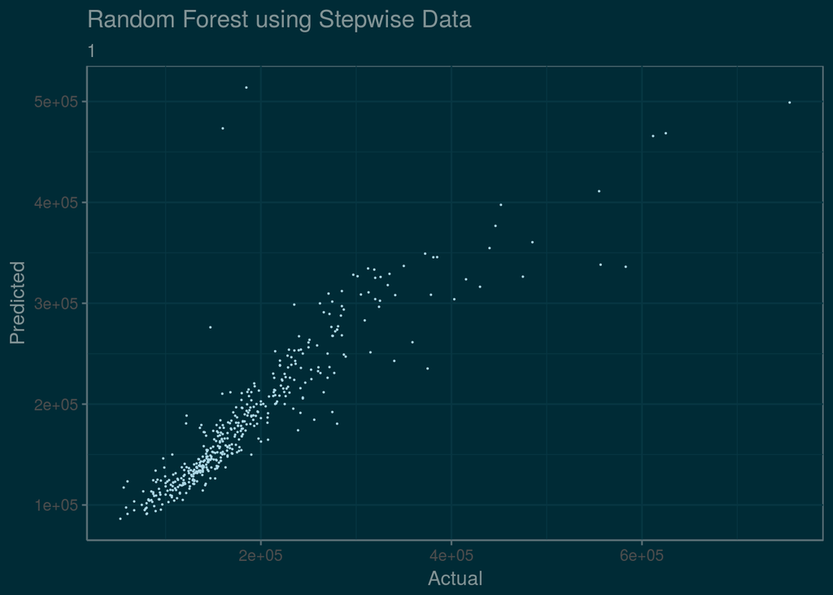

```r
rf.model = randomForest(formula = SalePrice ~ MSSubClass + LotArea + OverallQual +
    OverallCond + YearBuilt + YearRemodAdd + MasVnrArea + BsmtFinSF1 +
    BsmtFinSF2 + BsmtUnfSF + X1stFlrSF + X2ndFlrSF + BsmtFullBath +
    HalfBath + BedroomAbvGr + KitchenAbvGr + TotRmsAbvGrd + Fireplaces +
    GarageCars + GarageArea + WoodDeckSF + ScreenPorch + PoolArea +
    MiscVal, data = na.omit(numericDataTrain))

rf.pred = predict(rf.model, numericDataTest)

predictionDataFrame = data.frame(actual = numericDataTest$SalePrice, predicted = rf.pred)


ggplot(predictionDataFrame, aes(x = actual, y = predicted)) +
     geom_point(cex = .05, colour = "light blue") +
     theme_solarized(light = FALSE)+
     xlab("Actual") +
     ylab("Predicted") +
     ggtitle(paste("Random Forest using Stepwise Data"), "1")
```

Check with Kaggle

```r
actualTest = read.csv("test.csv")

rf.model = randomForest(formula = SalePrice ~ MSSubClass + LotArea + OverallQual +
    OverallCond + YearBuilt + YearRemodAdd + MasVnrArea + BsmtFinSF1 +
    BsmtFinSF2 + BsmtUnfSF + X1stFlrSF + X2ndFlrSF + BsmtFullBath +
    HalfBath + BedroomAbvGr + KitchenAbvGr + TotRmsAbvGrd + Fireplaces +
    GarageCars + GarageArea + WoodDeckSF + ScreenPorch + PoolArea +
    MiscVal, data = train, na.action = na.omit)

rf.pred = predict(rf.model, actualTest)

rf.pred[is.na(rf.pred)] = mean(na.omit(rf.pred))

sum(is.na(rf.pred))
```

```
## [1] 0
```

```r
SalePrice = cbind(Id = actualTest$Id, SalePrice = rf.pred)

head(SalePrice)
```

```
##     Id SalePrice
## 1 1461  128542.9
## 2 1462  154953.6
## 3 1463  169038.4
## 4 1464  178748.6
## 5 1465  190863.7
## 6 1466  193060.1
```

The Kaggle Score for the submission above was 0.15724 with a rank at 1739. Lot’s of room for improvement, but we’ve only used half the data! :)

# Thinking about Improvements

```r
actualTest = read.csv("test.csv")

rf.model = randomForest(formula = SalePrice ~ MSSubClass + LotArea + OverallQual +
    OverallCond + YearBuilt + YearRemodAdd + MasVnrArea + BsmtFinSF1 +
    BsmtFinSF2 + BsmtUnfSF + X1stFlrSF + X2ndFlrSF + BsmtFullBath +
    HalfBath + BedroomAbvGr + KitchenAbvGr + TotRmsAbvGrd + Fireplaces +
    GarageCars + GarageArea + WoodDeckSF + ScreenPorch + PoolArea +
    MiscVal, data = train, na.action = na.omit)

rf.pred = predict(rf.model, actualTest)

rf.pred[is.na(rf.pred)] = mean(na.omit(rf.pred))

sum(is.na(rf.pred))
```

```
## [1] 0
```

```r
SalePrice = cbind(Id = actualTest$Id, SalePrice = rf.pred)

head(SalePrice)
```

```
##     Id SalePrice
## 1 1461  128935.7
## 2 1462  154989.8
## 3 1463  170506.0
## 4 1464  182381.2
## 5 1465  187700.4
## 6 1466  192004.7
```